# Part II - Ford GoBike System Dataset Exploration

## by EYAMBE MPOULI Boris Claude

### Investigation Overview

We were interested to know about the trends in GoBike custmers behaviour to be able to improve the business. So we mainly focused on what are the features who impacted the most trips taken in terms of duration, time period of day, day of the week, and members characteristics such as gender, type, and age?

## Dataset Overview

- This dataset is taken from Ford GoBike a public bicycle sharing system in California, the data contained information about GoBike members and all trips that were taken by them in February 2019.

## Trip Duration

- Members’ bike trips usually take from 4 minutes to 10 minutes, and it’s rare they take more than 30 minutes.

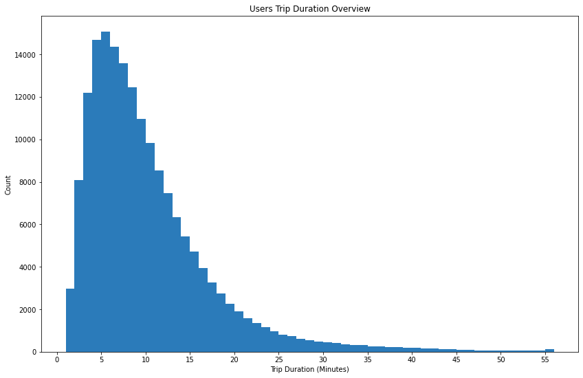

## Bike Share For All Trip

- A high percentage of GoBike members **90.09%** don't use GoBike share for their entire trip, while only **9.91%** are using it for their entire trip.

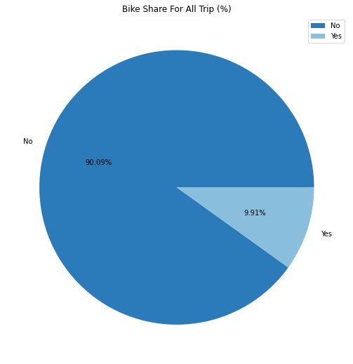

## Period of The Day and Day of the Week

- Tuesday and Thursday are the peaked days
- Afternoon is the peakest period
- Sunday and Saturday have the least number of trips.

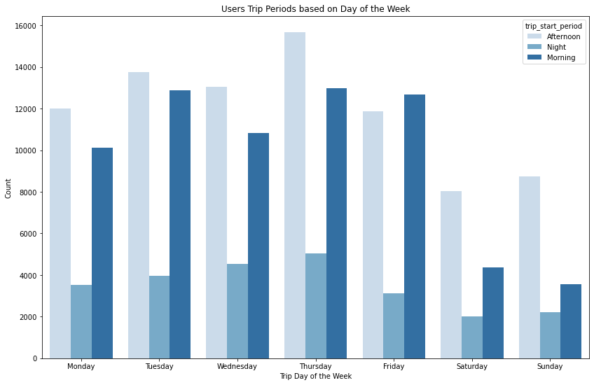

## Conclusion

> At the end of performing all these exploration steps, we found a lot of useful informations that can open a lot of interesting future opportunities to improve and promote the business.

> Since our work was just focused on the data for one month, it could be a good idea to enlarge his scope by working with data for 3, 6 months or even a year or more.

> And to deepen our work we could try to build a Machine Learning or Deep Learning model to predict or recognize patterns from our data.